```python
import pandas as pd
import numpy as np
import matplotlib.pyplot as plt

import plotly.express as px


import seaborn as sns
```

# What do the variables represent?

Age - age of the patient

Sex - gender of the patient (0 = female; 1 = male)

cp - type of chest pain from 0 to 3. Value 0: typical angina Value 1: atypical angina Value 2: non-anginal pain Value 3: asymptomatic

trtbps - resting blood pressure measured in mmHg

chol - cholesterol levels in mg/dL measured by BMI sensor

fbs - fasting blood sugar > 120 mg/dl (1 = true; 0 = false)

restecg - resting ECG results (1 = abnormal; 0 = normal)

thalachh - maximum heart rate

exng - exercise induced angina (1 = yes; 0 = no)

oldpeak - measurement used in exercise stress testing to evaluate the extent of ST segment depression observed on an electrocardiogram (ECG or EKG). higher values mean reduced blood flow to muscle aka ischemia (0.0 - 1.0 is normal risk, 1.0 - 2.0 is moderate risk, 2.0 and above is high risk)

slp - slope of ST depression (0 = less indicative of ischemia; 1 = borderline or equivocal changes; 2 = more suggestive of ischemia especially if occurs during exercise stress testing)

caa - number of major vessels (0 - 3)

thall - thal rate (0 = normal; 1 = reduced blood flow to heart in specific area; 2 = reduced blood flow to heart in certain areas when exercising but at rest normal; 3 = normal or indeterminate results)

output - occurrence of heart attack (0 = no heart attack; 1 = heart attack)

```python
df = pd.read_csv('data/heart.csv', delimiter = ',')
df.head()
```

|  | age | sex | cp | trtbps | chol | fbs | restecg | thalachh | exng | oldpeak | slp | caa | thall | output |
| --- | --- | --- | --- | --- | --- | --- | --- | --- | --- | --- | --- | --- | --- | --- |
| 0 | 63 | 1 | 3 | 145 | 233 | 1 | 0 | 150 | 0 | 2.3 | 0 | 0 | 1 | 1 |
| 1 | 37 | 1 | 2 | 130 | 250 | 0 | 1 | 187 | 0 | 3.5 | 0 | 0 | 2 | 1 |
| 2 | 41 | 0 | 1 | 130 | 204 | 0 | 0 | 172 | 0 | 1.4 | 2 | 0 | 2 | 1 |
| 3 | 56 | 1 | 1 | 120 | 236 | 0 | 1 | 178 | 0 | 0.8 | 2 | 0 | 2 | 1 |
| 4 | 57 | 0 | 0 | 120 | 354 | 0 | 1 | 163 | 1 | 0.6 | 2 | 0 | 2 | 1 |

```python
df.isna().sum()
```

```
age         0
sex         0
cp          0
trtbps      0
chol        0
fbs         0
restecg     0
thalachh    0
exng        0
oldpeak     0
slp         0
caa         0
thall       0
output      0
dtype: int64
```

```python
df.describe()
```

|  | age | sex | cp | trtbps | chol | fbs | restecg | thalachh | exng | oldpeak | slp | caa | thall | output |
| --- | --- | --- | --- | --- | --- | --- | --- | --- | --- | --- | --- | --- | --- | --- |
| count | 303.000000 | 303.000000 | 303.000000 | 303.000000 | 303.000000 | 303.000000 | 303.000000 | 303.000000 | 303.000000 | 303.000000 | 303.000000 | 303.000000 | 303.000000 | 303.000000 |
| mean | 54.366337 | 0.683168 | 0.966997 | 131.623762 | 246.264026 | 0.148515 | 0.528053 | 149.646865 | 0.326733 | 1.039604 | 1.399340 | 0.729373 | 2.313531 | 0.544554 |
| std | 9.082101 | 0.466011 | 1.032052 | 17.538143 | 51.830751 | 0.356198 | 0.525860 | 22.905161 | 0.469794 | 1.161075 | 0.616226 | 1.022606 | 0.612277 | 0.498835 |
| min | 29.000000 | 0.000000 | 0.000000 | 94.000000 | 126.000000 | 0.000000 | 0.000000 | 71.000000 | 0.000000 | 0.000000 | 0.000000 | 0.000000 | 0.000000 | 0.000000 |
| 25% | 47.500000 | 0.000000 | 0.000000 | 120.000000 | 211.000000 | 0.000000 | 0.000000 | 133.500000 | 0.000000 | 0.000000 | 1.000000 | 0.000000 | 2.000000 | 0.000000 |
| 50% | 55.000000 | 1.000000 | 1.000000 | 130.000000 | 240.000000 | 0.000000 | 1.000000 | 153.000000 | 0.000000 | 0.800000 | 1.000000 | 0.000000 | 2.000000 | 1.000000 |
| 75% | 61.000000 | 1.000000 | 2.000000 | 140.000000 | 274.500000 | 0.000000 | 1.000000 | 166.000000 | 1.000000 | 1.600000 | 2.000000 | 1.000000 | 3.000000 | 1.000000 |
| max | 77.000000 | 1.000000 | 3.000000 | 200.000000 | 564.000000 | 1.000000 | 2.000000 | 202.000000 | 1.000000 | 6.200000 | 2.000000 | 4.000000 | 3.000000 | 1.000000 |

# What the means of trtbps and cholesterol tell us about the dataset

The mean of trtbps (systolic resting blood pressure) and mean of cholesterol in this dataset show us that most of the patients in this data set had high trtbps and cholesterol. As measured by the American Heart Association (AHA), a trtbps of less than 120 mmHg is normal, 120-129 elevated, 130-139 hypertension stage 1, 140 and higher hypertension stage 2. Furthermore, the AHA identifies a cholesterol of less than 200 mg/dL as desirable, 200-239 borderline high, 240 and above as high. According to these standards, the patients in this dataset have, on average, hypertension stage 1 and very high cholesterol levels. Although this could be relative to the fact that the mean age of the dataset is 54, the two are still very high.

```python
# all features are numerical

df.info()
```

```
<class 'pandas.core.frame.DataFrame'>
RangeIndex: 303 entries, 0 to 302
Data columns (total 14 columns):
 #   Column    Non-Null Count  Dtype
---  ------    --------------  -----
 0   age       303 non-null    int64
 1   sex       303 non-null    int64
 2   cp        303 non-null    int64
 3   trtbps    303 non-null    int64
 4   chol      303 non-null    int64
 5   fbs       303 non-null    int64
 6   restecg   303 non-null    int64
 7   thalachh  303 non-null    int64
 8   exng      303 non-null    int64
 9   oldpeak   303 non-null    float64
 10  slp       303 non-null    int64
 11  caa       303 non-null    int64
 12  thall     303 non-null    int64
 13  output    303 non-null    int64
dtypes: float64(1), int64(13)
memory usage: 33.3 KB
```

# Correlations

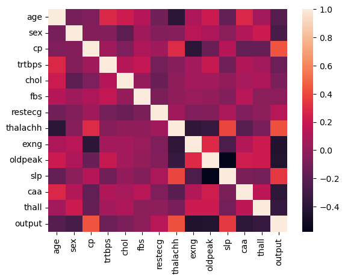

```python
df_corr = df.corr().transpose()
sns.heatmap(data=df_corr)
```

```python
for col in df_corr.columns:
    smallest = df_corr[col].nsmallest(2)
    smallest_name = smallest.index[-1]
    smallest_corr = smallest.iloc[-1]
    small = (smallest_name, smallest_corr)

    largest = df_corr[col].nlargest(2)
    largest_name = largest.index[1]
    largest_corr = largest.iloc[1]
    large = (largest_name, largest_corr)

    if abs(smallest_corr) > largest_corr:
        strongest = small
    else:
        strongest = large

    print(f'{col} has strongest correlation of {strongest[1]} with {strongest[0]}\n')
```

```
age has strongest correlation of 0.27935090656128797 with trtbps

sex has strongest correlation of 0.21004109563720727 with thall

cp has strongest correlation of 0.4337982615068947 with output

trtbps has strongest correlation of 0.27935090656128797 with age

chol has strongest correlation of 0.21367795655956193 with age

fbs has strongest correlation of 0.17753054193445988 with trtbps

restecg has strongest correlation of 0.1372295028737731 with output

thalachh has strongest correlation of 0.4217409338106743 with output

exng has strongest correlation of -0.39428026849502196 with cp

oldpeak has strongest correlation of -0.4306960016873686 with output

slp has strongest correlation of 0.3867844098148192 with thalachh

caa has strongest correlation of 0.2763262440191394 with age

thall has strongest correlation of 0.2102441259826487 with oldpeak

output has strongest correlation of 0.4337982615068947 with cp
```

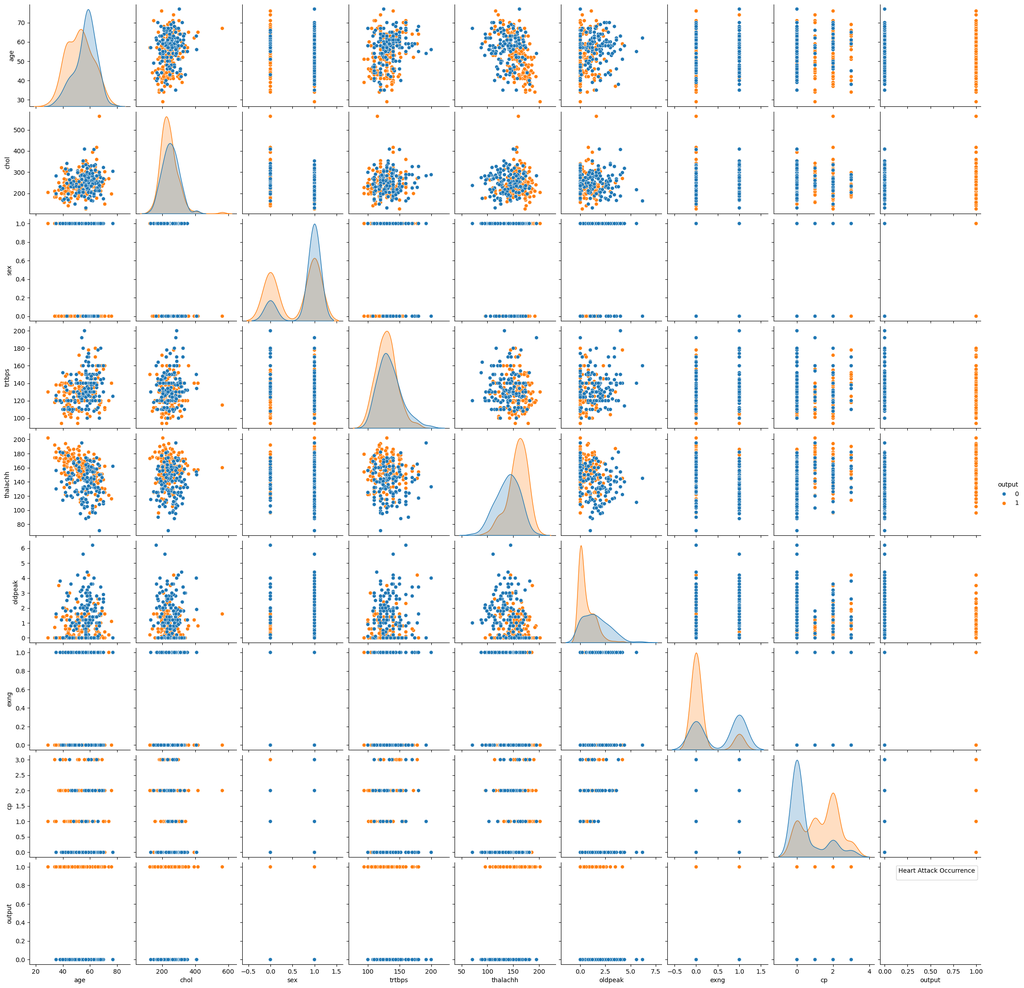

```python
test_cols = ['age', 'chol', 'sex', 'trtbps', 'thalachh', 'oldpeak', 'exng', 'cp', 'output']

sns.pairplot(
             data=df,
             vars=test_cols,
             hue = 'output',
            )
plt.show()
```

```python
output_correlations_pivot = df.pivot_table(index='output',
                                           values=['thalachh', 'oldpeak', 'exng', 'cp'],
                                           aggfunc=['mean', 'std']
                                          )
output_correlations_pivot
```

| output | mean cp | mean exng | mean oldpeak | mean thalachh | std cp | std exng | std oldpeak | std thalachh |
| --- | --- | --- | --- | --- | --- | --- | --- | --- |
| 0 | 0.478261 | 0.550725 | 1.585507 | 139.101449 | 0.905920 | 0.499232 | 1.300340 | 22.598782 |
| 1 | 1.375758 | 0.139394 | 0.583030 | 158.466667 | 0.952222 | 0.347412 | 0.780683 | 19.174276 |

# Hypothesis Testing Discrete Variables

## Null Hypothesis:

The type of chest pain has no relevance someone having a heart attack

## Alternate Hypothesis:

The type of chest pain has strong relevance to someone having a heart attack.

```python
from scipy.stats import f_oneway

anova_cp = [df[df['cp'] == i]['output'] for i in df['cp'].unique()]

f_oneway(*anova_cp)
```

```
F_onewayResult(statistic=np.float64(36.786781108607016), pvalue=np.float64(2.904720783531748e-20))
```

### Observation:

The type of chest pain has a strong impact on if someone has a heart attack. The statistic of about 36.787 represents the variance between the means of output of different groups. Since it is a high statistic, it shows that there is a large difference in someone having a heart attack depending on what type of chest pain they are having. The pvalue which is 2.9e-20 is extremely low which shows significant results where we reject the null. This means that the type of chest pain does have a relevance to someone having a heart attack.

Below, we show that this is an accurate description. People that had a chest pain of type 0 (typical angina) were much more likely to have an output of no heart attack while people with types 1 or 2 which represent atypical angina and non-anginal pain respectively had a higher likelihood of having a heart attack.

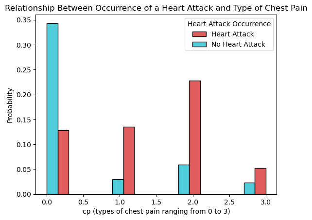

```python
label_dict = {
    '0': 'No Heart Attack',
    '1': 'Heart Attack'
}

colors = [sns.color_palette('tab10')[-1], sns.color_palette('tab10')[3]]
sns.set_palette(colors)
sns.histplot(data=df, x='cp', hue='output', multiple='dodge', stat='probability')
plt.title('Relationship Between Occurrence of a Heart Attack and Type of Chest Pain')
plt.xlabel('cp (types of chest pain ranging from 0 to 3)')
plt.legend(title='Heart Attack Occurrence', labels=['Heart Attack', 'No Heart Attack'])
plt.show()
```

## Null Hypothesis:

The occurrence of exercise-induced angina does not have any impact on the occurrence of a heart attack.

## Alternate Hypothesis:

The occurrence of exercise-induced angina has a strong impact on the occurrence of a heart attack.

```python
anova_exng = [df[df['exng'] == i]['output'] for i in df['exng'].unique()]

f_oneway(*anova_exng)
```

```
F_onewayResult(statistic=np.float64(70.95243821639592), pvalue=np.float64(1.520813838331386e-15))
```

### Observation:

The occurrence of exercise-induced angina has a strong impact on the occurrence of a heart attack. As shown above, the anova test resulted in a statistic of about 70.95 which shows a strong variance between the means of output dependent on if someone had exng or not. The pvalue of 1.5e-15 shows that these results are significant so we reject the null.

As shown below, we see the histogram that was previously displayed that indicates people that did not have exng were more likely to have a heart attack than not. The reverse is true for those with exng.

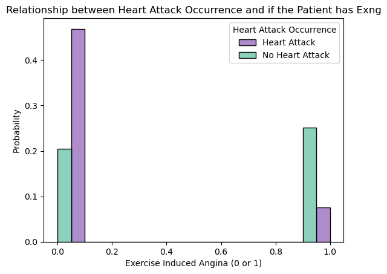

```python
colors = [sns.color_palette("Set2")[0], sns.color_palette("tab10")[4]]
sns.set_palette(colors)

sns.histplot(data=df, x='exng', hue='output', multiple='dodge', stat='probability')
plt.xlabel('Exercise Induced Angina (0 or 1)')
plt.title('Relationship between Heart Attack Occurrence and if the Patient has Exng')
plt.legend(title='Heart Attack Occurrence', labels=['Heart Attack', 'No Heart Attack'])
plt.show()
```

As seen below, this was undoubtedly the case. As such, I also tested to see if exng of 1 but different types of chest pain had a higher relevance to if a patient had a heart attack. In this analysis it is seen that people with exng of 1 were mostly classified has having a chest pain of type 0, which is accurate in relation to the description of the two variables. There were not many data points that had the other chest pain type classifications if they had exng of 1 and those that did had a slightly higher likelihood of experiencing a heart attack.

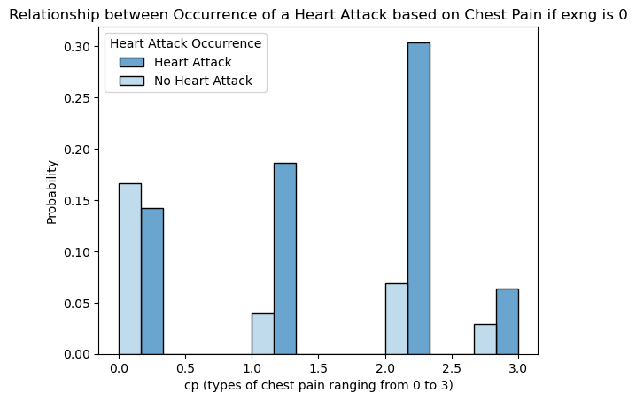

```python
exng_0 = df[df['exng'] == 0]
sns.histplot(data=exng_0, x='cp', hue='output', multiple='dodge', palette='Blues', stat='probability')
plt.title('Relationship between Occurrence of a Heart Attack based on Chest Pain if exng is 0')
plt.xlabel('cp (types of chest pain ranging from 0 to 3)')
plt.legend(title='Heart Attack Occurrence', labels=['Heart Attack', 'No Heart Attack'])
plt.show()
```

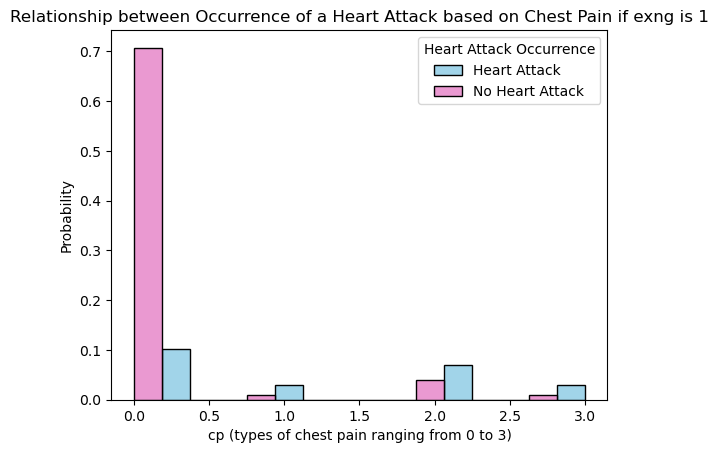

| exng | cp | output | count |
| --- | --- | --- | --- |
| 0 | 0 | 0 | 34 |
|  |  | 1 | 29 |
|  | 1 | 0 | 8 |
|  |  | 1 | 38 |
|  | 2 | 0 | 14 |
|  |  | 1 | 62 |
|  | 3 | 0 | 6 |
|  |  | 1 | 13 |
| 1 | 0 | 0 | 70 |
|  |  | 1 | 10 |
|  | 1 | 0 | 1 |
|  |  | 1 | 3 |
|  | 2 | 0 | 4 |
|  |  | 1 | 7 |
|  | 3 | 0 | 1 |
|  |  | 1 | 3 |

```python
colors = [sns.color_palette("tab10")[-4], sns.color_palette("muted")[-1]]

exng_1 = df[df['exng'] == 1]
sns.histplot(data=exng_1, x='cp', hue='output', multiple='dodge', palette=colors, stat='probability')
plt.title('Relationship between Occurrence of a Heart Attack based on Chest Pain if exng is 1')
plt.xlabel('cp (types of chest pain ranging from 0 to 3)')
plt.legend(title='Heart Attack Occurrence', labels=['Heart Attack', 'No Heart Attack'])
plt.show()

df.groupby(['exng', 'cp', 'output']).count()[['age']].rename(columns={'age':'count'})
```

# Hypothesis Testing Continuous Variables

## Null Hypothesis:

The mean thalachh (maximum heart rate achieved) will not be different between the group that has the occurrence of a heart attack and the group that does not.

## Alternate Hypothesis:

The mean thalachh will be different between the group that has the occurrence of a heart attack and the group that does not.

```python
from scipy.stats import ttest_ind

thalachh_0 = df[df['output'] == 0]['thalachh']
thalachh_1 = df[df['output'] == 1]['thalachh']

ttest_ind(thalachh_0, thalachh_1)
```

```
TtestResult(statistic=np.float64(-8.069702869452568), pvalue=np.float64(1.697337638656049e-14), df=np.float64(301.0))
```

### Observation:

The t-test performed for thalachh above shows a statistic of -8 and pvalue of 1.7e-14. This means that the first group which is no heart attack has a much lower mean thalachh than that of the group which has a heart attack. The low pvalue makes this result significant and as such we reject the null.

This observation is clear when looking at the histogram below which shows that people with higher thalachh experience heart attacks at a much higher likelihood. The mean for both is shown below as well.

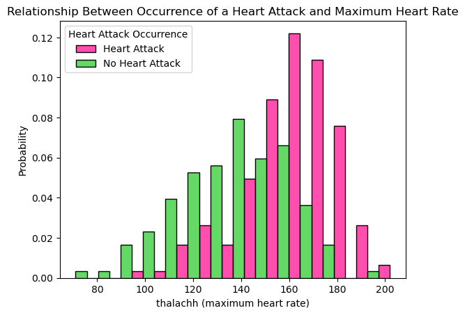

```
The mean thalachh for people classified under No Heart Attack is 139.1014492753623.
The mean thalachh for people classified under Heart Attack is 158.46666666666667
```

```python
colors = ["#FF1493", "#32CD32"]


sns.histplot(data=df, x='thalachh', hue='output', multiple='dodge', palette=colors[::-1], stat='probability')
plt.xlabel("thalachh (maximum heart rate)")
plt.title("Relationship Between Occurrence of a Heart Attack and Maximum Heart Rate")
plt.legend(title='Heart Attack Occurrence', labels=['Heart Attack', 'No Heart Attack'])
plt.show()

print(f'The mean thalachh for people classified under No Heart Attack is {thalachh_0.mean()}.\nThe mean thalachh for people classified under Heart Attack is {thalachh_1.mean()}')
```

## Null Hypothesis:

The mean oldpeak will not be different between the group that has the occurrence of a heart attack and the group that does not.

## Alternate Hypothesis:

The mean oldpeak will be different between the group that has the occurrence of a heart attack and the group that does not.

```python
oldpeak_0 = df[df['output'] == 0]['oldpeak']
oldpeak_1 = df[df['output'] == 1]['oldpeak']

ttest_ind(oldpeak_0, oldpeak_1)
```

```
TtestResult(statistic=np.float64(8.279579663866222), pvalue=np.float64(4.085346391354627e-15), df=np.float64(301.0))
```

### Observations:

As we can see above, the t-test performed is very significant with a pvalue of 4.09e-15. As such, we reject the null and say that the mean oldpeak will be different between the group that has the occurrence of a heart attack and the group that does not.

If we look at the histogram below, we can see that this is very true due to the fact that there is a large amount of people that have an oldpeak between 0 and 1 that have a heart attack. As such, the mean oldpeak for those with no heart attack is much higher than that of people that do not have a heart attack. However, we must perform another test as the accuracy of a classifier would not be high if we simply identified everybody with an oldpeak between 0 and 1 as having a heart attack and not having a heart attack otherwise.

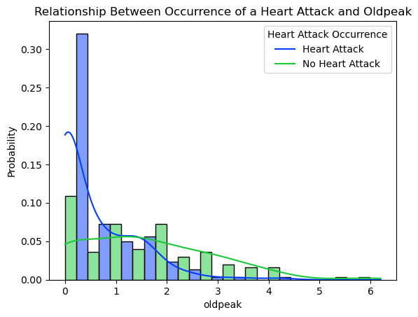

```
The mean oldpeak for people with output 0 is 1.5855072463768116.
The mean oldpeak for people with output 1 is 0.583030303030303
```

```python
colors = [sns.color_palette("bright")[0], sns.color_palette("bright")[2]]

sns.histplot(data=df, x='oldpeak', hue='output', multiple='dodge', kde=True, palette=colors[::-1], stat='probability')
plt.legend(title='Heart Attack Occurrence', labels=['Heart Attack', 'No Heart Attack'])
plt.title('Relationship Between Occurrence of a Heart Attack and Oldpeak')
plt.show()

print(f'The mean oldpeak for people with output 0 is {oldpeak_0.mean()}.\nThe mean oldpeak for people with output 1 is {oldpeak_1.mean()}')
```

### Using data from above

When looking at the oldpeak graph it is clear that the risk of heart attack is only higher or around the same when oldpeak is between 0 and 1. As such, I utilize these observations to see if we can get a more significant test result by creating a categorical variable on if oldpeak is greater than or equal to 1 and if oldpeak is less than 1. I then test for significance between thalachh and output through these split groups.

## Null Hypothesis:

(1) Patients with an oldpeak of less than 1.0 will not have a differing mean thalachh between the group within this that has a heart attack and the group that does not have a heart attack.

(2) Patients with an oldpeak of greater than or equal to 1.0 will not have a differing mean thalachh between the group within this that has a heart attack and the group that does not have a heart attack.

## Alternate Hypothesis:

(1) Patients with an oldpeak of less than 1.0 will have a differing mean thalachh between the group within this that has a heart attack and the group that does not have a heart attack.

(2) Patients with an oldpeak of greater than or equal to 1.0 will have a differing mean thalachh between the group within this that has a heart attack and the group that does not have a heart attack.

```
TtestResult(statistic=np.float64(-3.2863115267329768), pvalue=np.float64(0.0012415580616499135), df=np.float64(164.0))
```

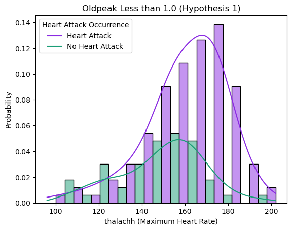

```python
# (1)
colors = [sns.color_palette("bright")[4], sns.color_palette("Dark2")[0]]

op_thalac_temp = df.copy()

# old_slp = df[['oldpeak', 'slp']]
# old_slp[old_slp['oldpeak'] < 1.0]['slp'].value_counts()

op_thalac_temp_true = op_thalac_temp[op_thalac_temp['oldpeak'] < 1.0]

true_group0 = op_thalac_temp_true[op_thalac_temp_true['output'] == 0]['thalachh']
true_group1 = op_thalac_temp_true[op_thalac_temp_true['output'] == 1]['thalachh']

sns.histplot(data=op_thalac_temp_true, x='thalachh', hue='output', multiple='dodge', kde=True, palette=colors[::-1], stat='probability')
plt.legend(title='Heart Attack Occurrence', labels=['Heart Attack', 'No Heart Attack'])
plt.xlabel('thalachh (Maximum Heart Rate)')
plt.title('Oldpeak Less than 1.0 (Hypothesis 1)')
ttest_ind(true_group0, true_group1)
```

```
TtestResult(statistic=np.float64(-3.2863115267329768), pvalue=np.float64(0.0012415580616499135), df=np.float64(164.0))
```

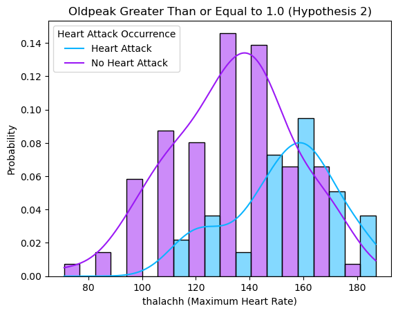

```python
# (2)
colors = ["#9b19f5", "#0bb4ff"]

op_thalac_temp_false = op_thalac_temp[op_thalac_temp['oldpeak'] >= 1.0]

false_group0 = op_thalac_temp_true[op_thalac_temp_true['output'] == 0]['thalachh']
false_group1 = op_thalac_temp_true[op_thalac_temp_true['output'] == 1]['thalachh']

sns.histplot(data=op_thalac_temp_false, x='thalachh', hue='output', multiple='dodge', kde=True, palette=colors, stat='probability')
plt.legend(title='Heart Attack Occurrence', labels=['Heart Attack', 'No Heart Attack'])
plt.xlabel('thalachh (Maximum Heart Rate)')
plt.title('Oldpeak Greater Than or Equal to 1.0 (Hypothesis 2)')
ttest_ind(false_group0, false_group1)
```

### Observations:

If we just look at one column and classify people based on that, the accuracy of our predictions will be incredibly low. However, if we perform tests to determine a significance in the differing impact on the occurrence of a heart attack by looking at multiple variables, we can create a more accurate classifier.

```python
df['sex'].value_counts()
```

```
sex
1    207
0     96
Name: count, dtype: int64
```

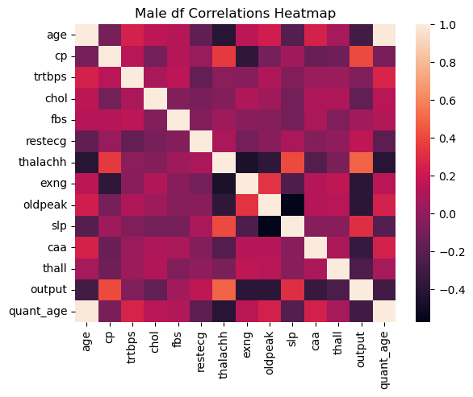

```
Male correlations greater than original df correlations
```

|  | age | cp | trtbps | chol | fbs | restecg | thalachh | exng | oldpeak | slp | caa | thall | output | quant_age |
| --- | --- | --- | --- | --- | --- | --- | --- | --- | --- | --- | --- | --- | --- | --- |
| age | False | True | False | False | True | True | True | True | True | True | False | True | True | False |
| cp | True | False | True | True | True | False | True | False | False | False | False | False | False | True |
| trtbps | False | True | False | False | False | True | False | False | False | False | False | False | False | False |
| chol | False | True | False | False | True | False | True | True | False | True | True | True | True | False |
| fbs | True | True | False | True | False | False | True | True | True | True | False | True | True | True |
| restecg | True | False | True | False | False | False | True | True | False | True | False | False | True | True |
| thalachh | True | True | False | True | True | True | False | True | True | True | True | False | True | True |
| exng | True | False | False | True | True | True | True | False | True | False | True | False | False | True |
| oldpeak | True | False | False | False | True | False | True | True | False | False | False | False | False | True |
| slp | True | False | False | True | True | True | True | False | False | False | False | False | False | True |
| caa | False | False | False | True | False | False | True | True | False | False | False | False | False | False |
| thall | True | False | False | True | True | False | False | False | False | False | False | False | False | True |
| output | True | False | False | True | True | True | True | False | False | False | False | False | False | True |
| quant_age | False | True | False | False | True | True | True | True | True | True | False | True | True | False |

```python
# now we see if splitting groups into male or female can impact the correlations above

male = df[df['sex'] == 1].drop(columns=['sex'])
female = df[df['sex'] == 0].drop(columns=['sex'])

male_corr = male.corr().transpose()


sns.heatmap(data=male_corr)
plt.title('Male df Correlations Heatmap')
plt.show()
temp_df_corr = df.drop(columns=['sex']).corr().transpose()
print('Male correlations greater than original df correlations')
abs(male_corr) > abs(temp_df_corr)
```

```python
for col in male_corr.columns:
    smallest = male_corr[col].nsmallest(2)
    smallest_name = smallest.index[-1]
    smallest_corr = smallest.iloc[-1]
    small = (smallest_name, smallest_corr)

    largest = male_corr[col].nlargest(2)
    largest_name = largest.index[1]
    largest_corr = largest.iloc[1]
    large = (largest_name, largest_corr)

    if abs(smallest_corr) > largest_corr:
        strongest = small
    else:
        strongest = large

    print(f'{col} has strongest correlation of {strongest[1]} with {strongest[0]}\n')
```

```
age has strongest correlation of 0.9864825408597161 with quant_age

cp has strongest correlation of 0.40713608333372764 with output

trtbps has strongest correlation of 0.264058285625008 with quant_age

chol has strongest correlation of 0.15898299844716926 with age

fbs has strongest correlation of 0.15545349992219779 with trtbps

restecg has strongest correlation of -0.18148656578388034 with age

thalachh has strongest correlation of 0.4855842059430107 with output

exng has strongest correlation of -0.3937195750045445 with output

oldpeak has strongest correlation of -0.39316908430766206 with output

slp has strongest correlation of 0.40757500490495524 with thalachh

caa has strongest correlation of 0.25364784557687575 with age

thall has strongest correlation of 0.1689069662999378 with exng

output has strongest correlation of 0.4855842059430107 with thalachh

quant_age has strongest correlation of 0.9864825408597161 with age
```

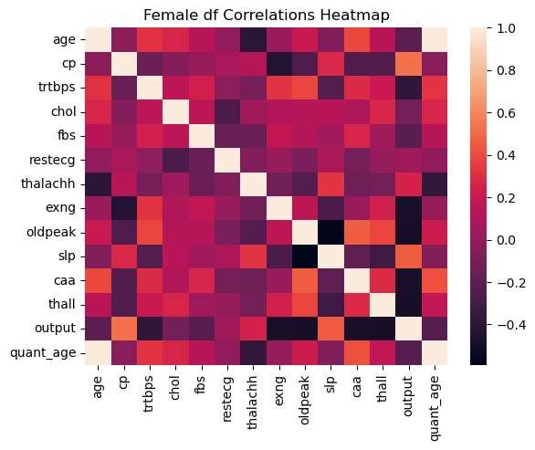

```
Female correlations greater than original df correlations
```

|  | age | cp | trtbps | chol | fbs | restecg | thalachh | exng | oldpeak | slp | caa | thall | output | quant_age |
| --- | --- | --- | --- | --- | --- | --- | --- | --- | --- | --- | --- | --- | --- | --- |
| age | False | False | True | True | True | False | True | False | False | False | True | True | False | True |
| cp | False | False | True | False | False | True | False | True | True | True | True | True | True | False |
| trtbps | True | True | False | True | True | False | True | True | True | True | True | True | True | True |
| chol | True | False | True | False | True | True | True | True | True | True | True | True | True | True |
| fbs | True | False | True | True | False | True | True | True | True | False | True | True | True | True |
| restecg | False | True | False | True | True | False | True | False | True | False | True | False | False | False |
| thalachh | True | False | True | True | True | True | False | False | False | False | False | True | False | False |
| exng | False | True | True | True | True | False | False | False | False | True | False | True | True | False |
| oldpeak | False | True | True | True | True | True | False | False | False | True | True | True | True | False |
| slp | False | True | True | True | False | False | False | True | True | False | True | True | True | False |
| caa | True | True | True | True | True | True | False | False | True | True | False | True | True | True |
| thall | True | True | True | True | True | False | True | True | True | True | True | False | True | True |
| output | False | True | True | True | True | False | False | True | True | True | True | True | False | False |
| quant_age | True | False | True | True | True | False | False | False | False | False | True | True | False | False |

```python
female_corr = female.corr().transpose()

sns.heatmap(data=female_corr)
plt.title('Female df Correlations Heatmap')
plt.show()
temp_df_corr = df.drop(columns=['sex']).corr().transpose()
print('Female correlations greater than original df correlations')
abs(female_corr) > abs(temp_df_corr)
```

```python
for col in female_corr.columns:
    smallest = female_corr[col].nsmallest(2)
    smallest_name = smallest.index[-1]
    smallest_corr = smallest.iloc[-1]
    small = (smallest_name, smallest_corr)

    largest = female_corr[col].nlargest(2)
    largest_name = largest.index[1]
    largest_corr = largest.iloc[1]
    large = (largest_name, largest_corr)

    if abs(smallest_corr) > largest_corr:
        strongest = small
    else:
        strongest = large

    print(f'{col} has strongest correlation of {strongest[1]} with {strongest[0]}\n')
```

```
age has strongest correlation of 0.9875239782778372 with quant_age

cp has strongest correlation of 0.5222329678670934 with output

trtbps has strongest correlation of 0.3883785202702279 with oldpeak

chol has strongest correlation of 0.2658322548712674 with thall

fbs has strongest correlation of 0.2650434252616605 with caa

restecg has strongest correlation of -0.16338375809592381 with fbs

thalachh has strongest correlation of -0.3741294455970433 with quant_age

exng has strongest correlation of -0.43341551198685097 with cp

oldpeak has strongest correlation of -0.5004538049643109 with output

slp has strongest correlation of 0.4582066604725425 with output

caa has strongest correlation of 0.46165226409517574 with oldpeak

thall has strongest correlation of 0.37888686890523093 with oldpeak

output has strongest correlation of 0.5222329678670934 with cp

quant_age has strongest correlation of 0.9875239782778372 with age
```

### Observations:

Due to the value counts of males being higher in this dataset, it has a stronger impact on the original df correlations. As such, it makes more sense to split the dataframes by sex and make the predictions based on if the new data point has sex 0 or sex 1.

When realizing this, it could be possible that we could create a classifier that combines a decision tree and a form of regression to be able to first split the data point into certain groups and perform tests that would lead to different probabilities on if the patient is going to have a heart attack or not.

# Machine Learning Model Setup and Completion

Outliers are classified as data that is more than 3 standard deviations above or below the mean. As such, I find the zscore of the data and find out if a column has outliers so that I can eliminate that data if I decide to use it as a feature.

```python
from sklearn.linear_model import LogisticRegression
from sklearn.metrics import accuracy_score, classification_report
from sklearn.pipeline import Pipeline, make_pipeline
from sklearn.preprocessing import StandardScaler, OrdinalEncoder, FunctionTransformer, QuantileTransformer
from sklearn.model_selection import train_test_split
from sklearn.compose import ColumnTransformer
from sklearn.model_selection import GridSearchCV, cross_val_score, KFold

from scipy.stats import zscore
```

```python
print((np.abs(zscore(df)) < 3).sum(axis=0))#.sum(axis=0))
print(f'Total number of rows is {df.shape[0]}')
```

```
age          303
sex          303
cp           303
trtbps       301
chol         299
fbs          303
restecg      303
thalachh     302
exng         303
oldpeak      301
slp          303
caa          298
thall        301
output       303
quant_age    303
dtype: int64
Total number of rows is 303
```

```python
# df[(np.abs(zscore(df)) < 3).all(axis=1)]
```

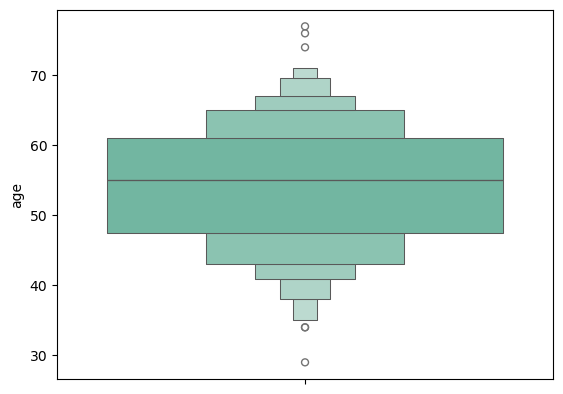

```python
sns.boxenplot(data=df['age'])
plt.show()
# should quantile transform and include age in the models
```

I believe it would be better to quantile transform the age first and creating a pipeline utilizing age while splitting the dataset into the male and female datasets seen above.

```python
# using male and female datasets separately

features_male = ['age', 'cp', 'oldpeak', 'thalachh']
target = 'output'


temp_male = male.copy()
no_outliers_male = temp_male[(np.abs(zscore(temp_male)) < 3).all(axis=1)]



X_male = no_outliers_male[features_male]
y_male = no_outliers_male[target]

X_train_male, X_test_male, y_train_male, y_test_male = train_test_split(
                                                                        X_male,
                                                                        y_male,
                                                                        test_size=0.2,
                                                                        random_state=42
                                                                        )

preproc = ColumnTransformer(
    transformers=[
        ('quantiles', QuantileTransformer(), ['age'])
    ],
    remainder='passthrough'
)

# Define the pipeline
pipeline = Pipeline([
    ('preprocessor', preproc),
    ('classifier', LogisticRegression())
])

param_grid = {
    'preprocessor__quantiles__n_quantiles': [i+1 for i in range(30)],
}

grid_search = GridSearchCV(pipeline, param_grid, cv=5, scoring='accuracy')

grid_search.fit(X_train_male, y_train_male)

best_param = grid_search.best_params_['preprocessor__quantiles__n_quantiles']
best_score = grid_search.best_score_

print(f"Best n_quantile: {best_param}")
print(f"Best cross-validation accuracy: {best_score}")

best_model = grid_search.best_estimator_
y_pred_male = best_model.predict(X_test_male)

print("Test set evaluation:")
print(classification_report(y_test_male, y_pred_male))


# As we can see, the accuracy for this model is not bad
# I try to see if changing some things or adding features will increase accuracy

# Something else I noticed is that for this specific model, age seems to be
# irrelevant to the features as having the n_quantile as 1 (which makes all age values 0)
# is the optimal n_quantiles. This means that age can be removed from the features

# Since output is a binary variable it is better to utilize precision and recall rather than rmse
```

```
Best n_quantile: 1
Best cross-validation accuracy: 0.8208333333333334
Test set evaluation:
              precision    recall  f1-score   support

           0       0.79      0.68      0.73        22
           1       0.68      0.79      0.73        19

    accuracy                           0.73        41
   macro avg       0.74      0.74      0.73        41
weighted avg       0.74      0.73      0.73        41
```

```python
# Trying to see if changing such that quantile applies to all improves accuracy

X = no_outliers_male[features_male]
y = no_outliers_male['output']

X_train, X_test, y_train, y_test = train_test_split(X, y, test_size=0.2, random_state=42)

model = Pipeline([
    ('quantile_transformer', QuantileTransformer(n_quantiles=4)),
    ('classifier', LogisticRegression())
])


kfold_accuracy = cross_val_score(model, X_train, y_train, cv=10, scoring='accuracy')

for i in range(len(kfold_accuracy)):
    print(f'Fold {i+1}: Accuracy score of {kfold_accuracy[i]}')
print(f'Mean CV Score: {sum(kfold_accuracy)/10}')

model.fit(X_train, y_train)

y_pred = model.predict(X_test)

print(classification_report(y_test, y_pred))

# as seen, accuracy actually decreases when quantile transforming all. As such, we just utilize transformation
# of age from now on for female dataset to see if it will have more of an impact
```

```
Fold 1: Accuracy score of 0.7647058823529411
Fold 2: Accuracy score of 0.7647058823529411
Fold 3: Accuracy score of 0.875
Fold 4: Accuracy score of 0.75
Fold 5: Accuracy score of 0.6875
Fold 6: Accuracy score of 0.8125
Fold 7: Accuracy score of 0.8125
Fold 8: Accuracy score of 0.8125
Fold 9: Accuracy score of 0.8125
Fold 10: Accuracy score of 0.75
Mean CV Score: 0.7841911764705882
              precision    recall  f1-score   support

           0       0.76      0.73      0.74        22
           1       0.70      0.74      0.72        19

    accuracy                           0.73        41
   macro avg       0.73      0.73      0.73        41
weighted avg       0.73      0.73      0.73        41
```

```python
# 'slp', 'exng', 'oldpeak', 'caa', 'cp' have highest relevant correlations (i.e. some have high correlation
# with each other while others have high correlation with output)

features_female = ['age', 'caa', 'cp']
target = 'output'

temp_female = female.copy()
#temp_female['output'] = female['output'].copy()

no_outliers_female = temp_female[(np.abs(zscore(temp_female)) < 3).all(axis=1)]

X_female = no_outliers_female[features_female]
y_female = no_outliers_female[target]

X_train_female, X_test_female, y_train_female, y_test_female = train_test_split(
                                                                                    X_female,
                                                                                    y_female,
                                                                                    test_size=0.2,
                                                                                    random_state=42
                                                                                )

preproc = ColumnTransformer(
    transformers=[
        ('age', QuantileTransformer(n_quantiles=3), ['age'])
    ],
    remainder='passthrough'
)

model = make_pipeline(preproc, LogisticRegression())

kfold_accuracy = cross_val_score(model, X_train_female, y_train_female, cv=5, scoring='accuracy')

for i in range(len(kfold_accuracy)):
    print(f'Fold {i+1}: Accuracy score of {kfold_accuracy[i]}')
print(f'Mean CV Score: {sum(kfold_accuracy)/5}')

model.fit(X_train_female, y_train_female)
y_pred_female = model.predict(X_test_female)

print(classification_report(y_test_female, y_pred_female))
print(accuracy_score(y_test_female, y_pred_female))

# big issue with this model is the fact that female information is quite low for output no heart attack
```

```
Fold 1: Accuracy score of 0.9333333333333333
Fold 2: Accuracy score of 0.8
Fold 3: Accuracy score of 0.8
Fold 4: Accuracy score of 0.7857142857142857
Fold 5: Accuracy score of 0.8571428571428571
Mean CV Score: 0.8352380952380951
              precision    recall  f1-score   support

           0       0.50      0.33      0.40         3
           1       0.88      0.94      0.91        16

    accuracy                           0.84        19
   macro avg       0.69      0.64      0.65        19
weighted avg       0.82      0.84      0.83        19

0.8421052631578947
```

```python
pl = make_pipeline(QuantileTransformer(n_quantiles=2), RandomForestClassifier(random_state=42))
pl.fit(X_train_female, y_train_female)
mean_cv_score = sum(cross_val_score(random, X_train_female, y_train_female, cv=5, scoring='accuracy'))/5
print(f'Mean CV Score of {mean_cv_score} through 5 folds')

print(classification_report(pl.predict(X_test_female), y_test_female))



## much better to use logistic regression
```

```
Mean CV Score of 0.7657142857142857 through 5 folds
              precision    recall  f1-score   support

           0       0.33      0.25      0.29         4
           1       0.81      0.87      0.84        15

    accuracy                           0.74        19
   macro avg       0.57      0.56      0.56        19
weighted avg       0.71      0.74      0.72        19
```

```python
pl = make_pipeline(QuantileTransformer(n_quantiles=2), RandomForestClassifier(random_state=42))
pl.fit(X_train_male, y_train_male)
print(sum(cross_val_score(random, X_train_male, y_train_male, cv=5, scoring='accuracy'))/5)

print(classification_report(pl.predict(X_test_male), y_test_male))

# CV score for logistic is better than randomforest
```

```
0.734280303030303
              precision    recall  f1-score   support

           0       0.68      0.65      0.67        23
           1       0.58      0.61      0.59        18

    accuracy                           0.63        41
   macro avg       0.63      0.63      0.63        41
weighted avg       0.64      0.63      0.64        41
```

# Best model for just male dataset

```python
# Try seeing what including all of the features would do

X_new = no_outliers_male.copy().drop(columns=['output', 'age'])
y_new = no_outliers_male.copy()['output']

X_new_train, X_new_test, y_new_train, y_new_test = train_test_split(
                                                                    X_new,
                                                                    y_new,
                                                                    test_size=0.2,
                                                                    random_state=42
                                                                    )

pl = make_pipeline(LogisticRegression(max_iter=1000))

cv_new_test = cross_val_score(pl, X_new_train, y_new_train, cv=5, scoring='accuracy')

for i, j in enumerate(cv_new_test):
    print(f'Fold {i+1}: CV score of {j}')
print(f'Mean cv score: ', sum(cv_new_test)/5)

pl.fit(X_new_train, y_new_train)
y_new_pred = pl.predict(X_new_test)

print(classification_report(y_new_pred, y_new_test))
```

```
Fold 1: CV score of 0.7878787878787878
Fold 2: CV score of 0.8484848484848485
Fold 3: CV score of 0.8125
Fold 4: CV score of 0.8125
Fold 5: CV score of 0.78125
Mean cv score:  0.8085227272727273
              precision    recall  f1-score   support

           0       0.73      0.84      0.78        19
           1       0.84      0.73      0.78        22

    accuracy                           0.78        41
   macro avg       0.78      0.78      0.78        41
weighted avg       0.79      0.78      0.78        41
```

```python
X_new = no_outliers_female.copy().drop(columns='output')
y_new = no_outliers_female.copy()['output']

X_new_train, X_new_test, y_new_train, y_new_test = train_test_split(
                                                                    X_new,
                                                                    y_new,
                                                                    test_size=0.2,
                                                                    random_state=42
                                                                    )

preproc = ColumnTransformer(
    transformers=[
        ('age', QuantileTransformer(n_quantiles=4), ['age'])
    ],
    remainder='passthrough'
)
pl = make_pipeline(preproc, LogisticRegression(max_iter=1000))

cv_new_test = cross_val_score(pl, X_new_train, y_new_train, cv=5, scoring='accuracy')

for i, j in enumerate(cv_new_test):
    print(f'Fold {i+1}: CV score of {j}')
print(f'Mean cv score: ', sum(cv_new_test)/5)

pl.fit(X_new_train, y_new_train)
y_new_pred = pl.predict(X_new_test)

print(classification_report(y_new_pred, y_new_test))
```

```
Fold 1: CV score of 0.9333333333333333
Fold 2: CV score of 0.8666666666666667
Fold 3: CV score of 0.8666666666666667
Fold 4: CV score of 0.9285714285714286
Fold 5: CV score of 0.9285714285714286
Mean cv score:  0.9047619047619049
              precision    recall  f1-score   support

           0       0.33      1.00      0.50         1
           1       1.00      0.89      0.94        18

    accuracy                           0.89        19
   macro avg       0.67      0.94      0.72        19
weighted avg       0.96      0.89      0.92        19
```

# Best model for female dataset

As seen below, the best model for the female dataset uses multiple features and is much different from that of the male dataset. After messing with the features a lot by trying multiple combinations and seeing what might improve accuracy or the f1-score, it seems as though the best f1-score the model on classifying if females have a heart attack has a max f1-score of 0.50 for output no heart attack. This is most likely due to the lack of data on patients that are female and have a label under output as 0 which means the only way to make this model better is through finding more data on female patients that have an output of 0 and training the model on that data. This can allow for better f1-scores which emans the model will generalize well to unseen data and will be able to accurately predict if someone has a high likelihood for a heart attack or not. However, by adding some more features we were able to make the model have an average kfold cross-validation score of 91.8 percent over 5 folds.

```python
# all_features = ['age', 'cp', 'trtbps', 'chol', 'fbs', 'restecg', 'thalachh', 'exng',
#       'oldpeak', 'slp', 'caa', 'thall']

features = ['age', 'trtbps', 'cp', 'fbs',
       'slp', 'caa', 'thall']

X = no_outliers_female[features]
y = no_outliers_female['output']

X_train, X_test, y_train, y_test = train_test_split(X, y,test_size=0.2, random_state=42)

preproc = ColumnTransformer(
    transformers=[
        ('age', QuantileTransformer(n_quantiles=2), ['age'])
    ],
    remainder='passthrough'
)
model = make_pipeline(preproc, LogisticRegression(max_iter=1000))

cv_scores = cross_val_score(model, X_train, y_train, cv=5, scoring='accuracy')

for i, score in enumerate(cv_scores):
    print(f'Fold {i+1}: CV score of {score}')

print(sum(cv_scores)/5)

model.fit(X_train, y_train)
y_pred = model.predict(X_test)

print(classification_report(y_pred, y_test))
```

```
Fold 1: CV score of 0.9333333333333333
Fold 2: CV score of 0.9333333333333333
Fold 3: CV score of 0.8666666666666667
Fold 4: CV score of 0.9285714285714286
Fold 5: CV score of 0.9285714285714286
0.9180952380952382
              precision    recall  f1-score   support

           0       0.33      1.00      0.50         1
           1       1.00      0.89      0.94        18

    accuracy                           0.89        19
   macro avg       0.67      0.94      0.72        19
weighted avg       0.96      0.89      0.92        19
```

# Using original df without separating based on sex

```python
temp_df = df.copy()
no_outliers = temp_df[(np.abs(zscore(temp_df)) < 3).all(axis=1)].copy()

no_outliers.drop(columns=['quant_age'], inplace=True)

features = ['age', 'sex', 'cp', 'trtbps',  'restecg', 'thalachh', 'exng',
      'oldpeak', 'slp', 'caa', 'thall']

X = no_outliers[features]
y = no_outliers['output']

X_train, X_test, y_train, y_test = train_test_split(X, y,test_size=0.2, random_state=42)

preproc = ColumnTransformer(
    transformers=[
        ('age', QuantileTransformer(n_quantiles=3), ['age']),
        ('oldpeak', StandardScaler(), ['oldpeak'])
    ],
    remainder='passthrough'
)
model = make_pipeline(preproc, LogisticRegression(max_iter=10000))

cv_scores = cross_val_score(model, X_train, y_train, cv=5, scoring='accuracy')

for i, score in enumerate(cv_scores):
    print(f'Fold {i+1}: CV score of {score}')

print(sum(cv_scores)/5)

model.fit(X_train, y_train)
y_pred = model.predict(X_test)

print(classification_report(y_pred, y_test))
```

```
Fold 1: CV score of 0.9130434782608695
Fold 2: CV score of 0.8478260869565217
Fold 3: CV score of 0.8695652173913043
Fold 4: CV score of 0.8478260869565217
Fold 5: CV score of 0.8
0.8556521739130434
              precision    recall  f1-score   support

           0       0.74      0.77      0.76        22
           1       0.86      0.83      0.85        36

    accuracy                           0.81        58
   macro avg       0.80      0.80      0.80        58
weighted avg       0.81      0.81      0.81        58
```